# LIAM Simulations: Outcomes and simulation settings

2025-02-05

## Simulation 1: Hebbian learning of connection strength

Setup:

- dispositions are all 0, and are kept static throughout the simulation
- attention is kept static at a moderately high value of 1 (to ensure learning can take place)
- importance and coupling are not included in this simulation
- learning and decay rates are set to .0003

Simulation 1A: connection weights are all set to 0 at the onset of the simulation (empty network)

Simulation 1B: connection weights are sampled from normal distribution with mean 0 and sd 0.1 (random network)

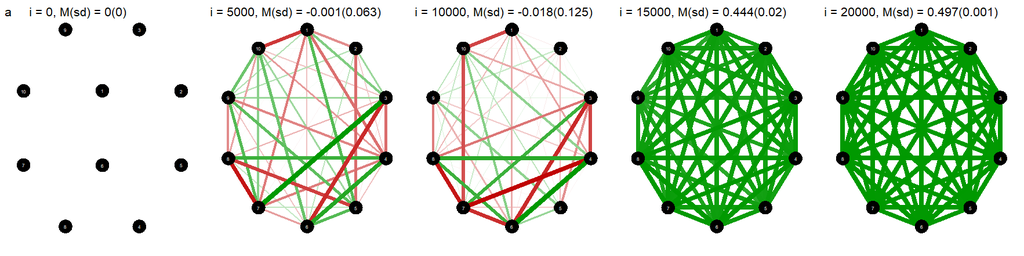

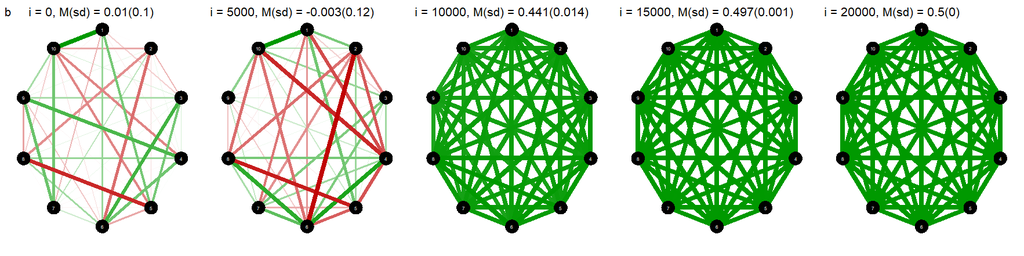

# Simulation 2: Effect of learning under varying attention parameters

Setup:

- dispositions are all 0, and are kept static throughout the simulation
- connection weights are sampled from normal distribution with mean 0.05 and sd 0.01
- importance and coupling are not included in this simulation
- learning and decay rates are set to .0003

Attention cycle (6 cycles in total):

- 400 iterations attention increases linearly from 0 to 2
- 400 iterations attention decreases linearly from 2 to 0
- 400 iterations attention remained at 0

Simulation 2A: No connection weight updating

Simulation 2B: With connection weight updating

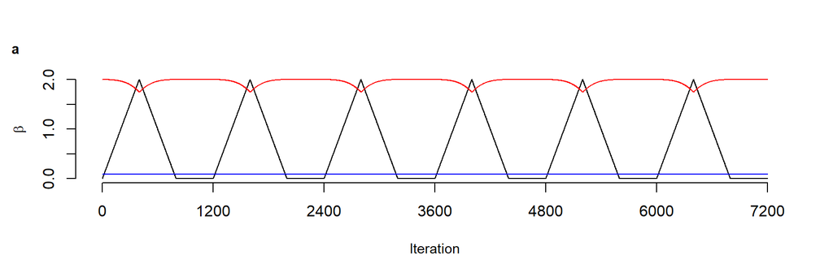

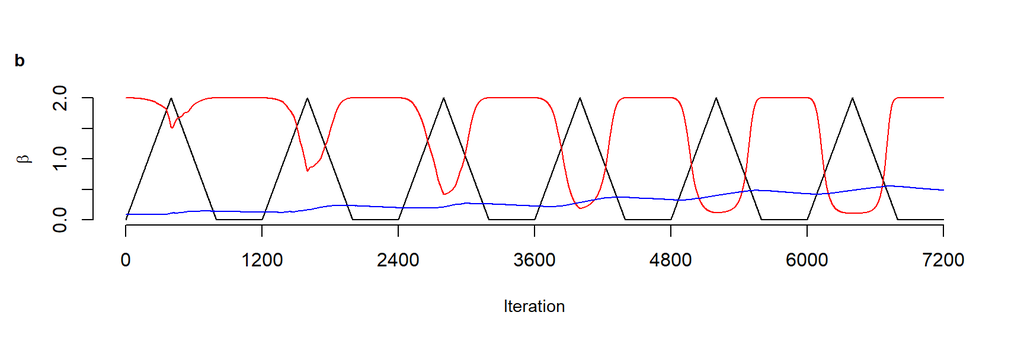

# Simulation 3: Effect of coupling unstableness and attention under varying importance parameters

- dispositions are all 0, and are kept static throughout the simulation
- initial connection weights are sampled from normal distribution with mean 0.05 and sd 0.01
- initial attention is set to 0
- coupling is set to .001
- learning and decay rates are set to .0003
- time window is set to 10 (i.e., the number of nodes)

Simulation 3A: Importance is set to 1 (low importance)

Simulation 3B: Importance is set to 2 (medium importance)

Simulation 3C: Importance is set to 3 (high importance)

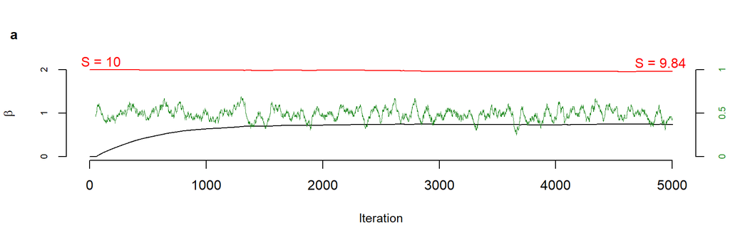

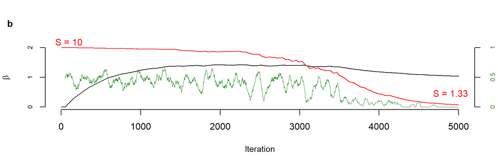

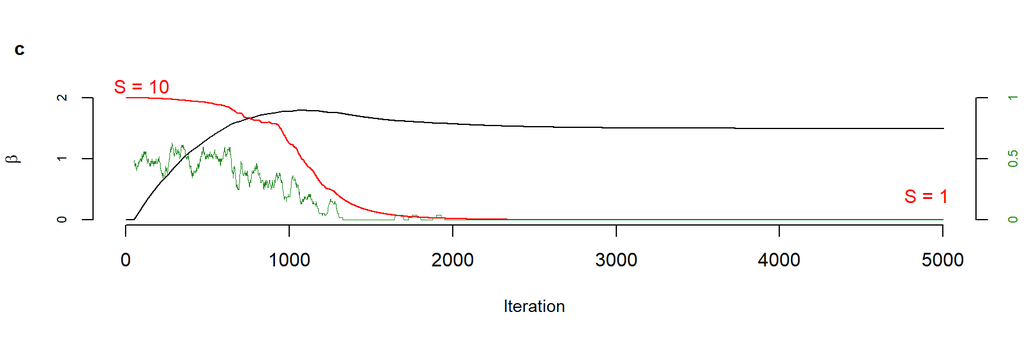

## Simulation 4: Effect of updating dispositions

Setup:

- dispositions are initially all -.05, except for one node, this disposition is set to .2
- connection weights are sampled from normal distribution with mean 0.05 and sd 0.01
- connection weight learning and disposition learning are enabled
- attention is kept static at a moderately high value of 1 (to ensure learning can take place)
- importance and coupling are not included in this simulation
- learning and decay rates are set to .0003

Outcome 4A shows a result where the incongruency is solved due to the positive disposition getting aligned with the rest of the network and become negative

Outcome 4B shows a result where the incongruency is solved due all other dispositions getting aligned with the strong positive disposition

Outcome 4C shows a result where the incongruency is not solved and an inconsistent network emerges

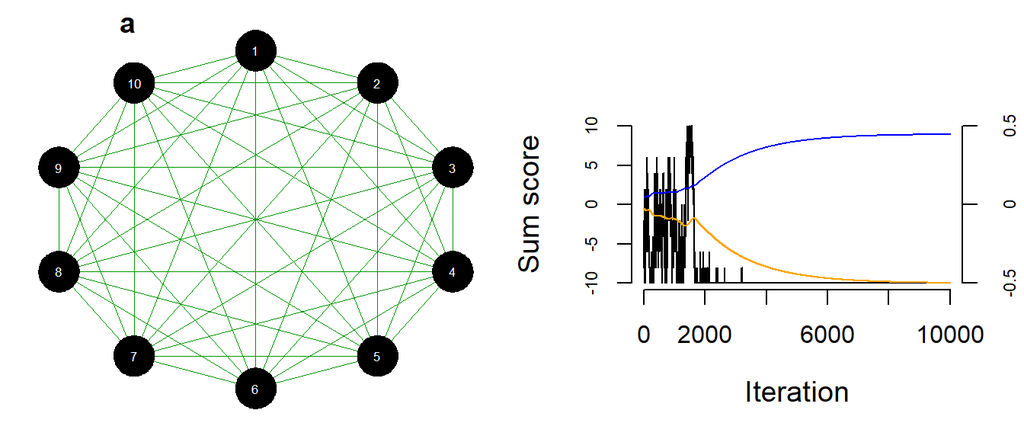

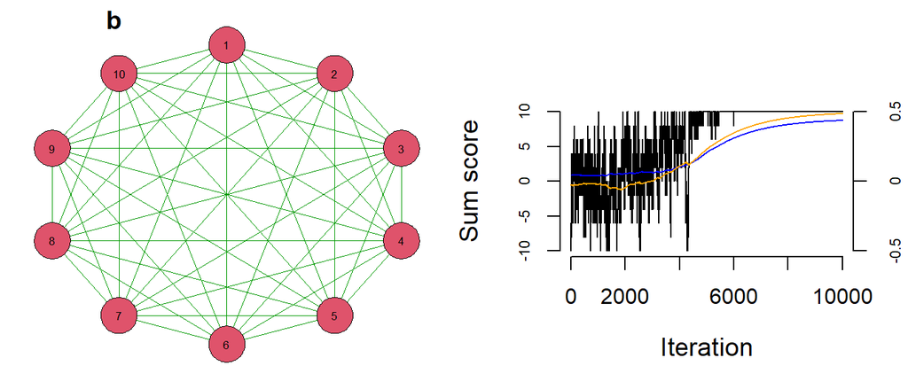

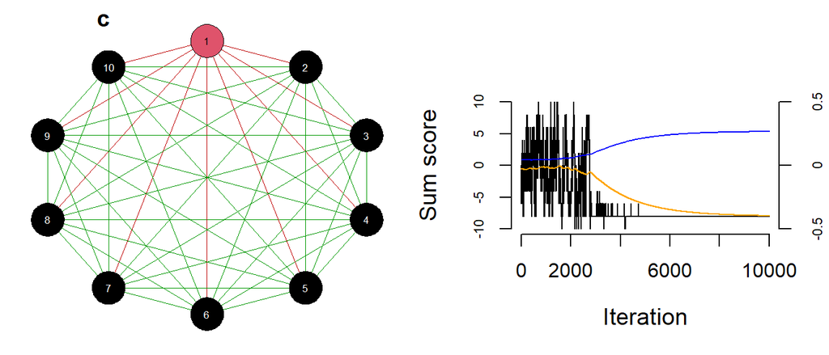

## Simulation 5: Attitude change via importance

Setup:

The intervention takes place at iteration 1001. There are four conditions:

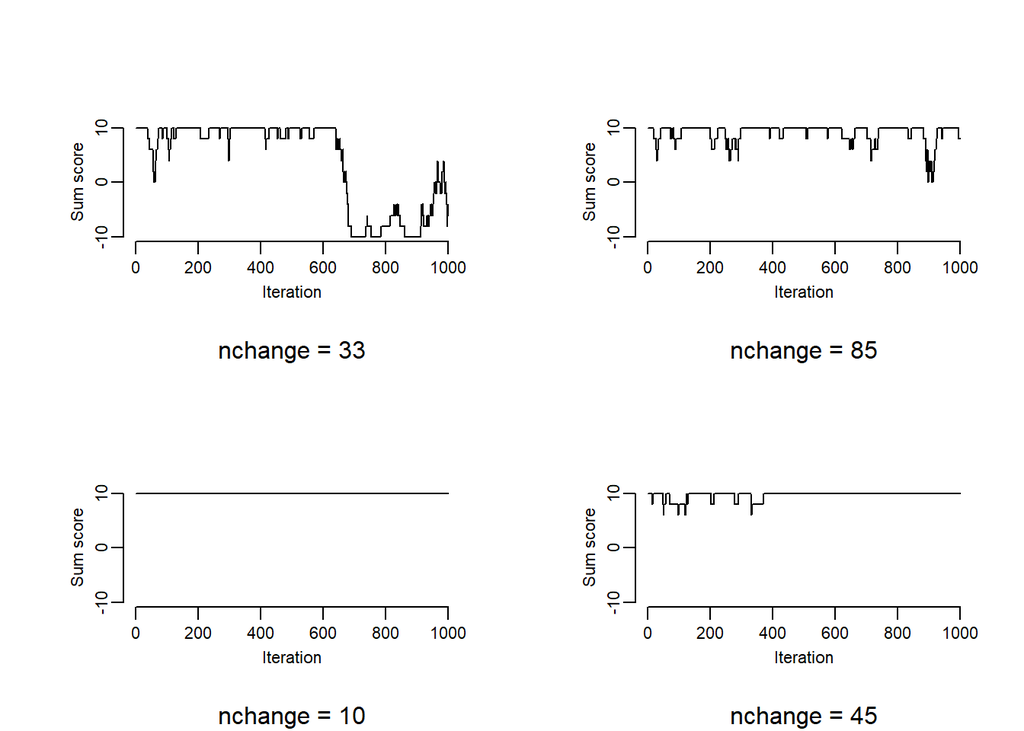